# Introduction to Topic Modeling

Topic Modeling is a form of unsupervised machine learning. It is a kind of text mining that doesn’t search for particular, predetermined content, but instead ‘reads’ an entire corpus and extracts a set of topics. Its unclear, and a point of debate, whether the topics are read / discovered from the corpus or whether the topics are ‘asserted’ as a description of the corpus.

There are a number of tools for topic modeling: the most common is probably MALLET.

Mallet is effective and can be useful but it requires a fair amount of command line programming. For a quick primer on installing and using mallet look here: http://programminghistorian.org/lessons/topic-modeling-and-mallet

Instead of trying to navigate MALLET’s difficult interface, we’ll do our topic modeling in R. If we wanted, we could also install the MALLET package for R which allows us to run MALLET in R. But this requires that we first install MALLET on our local machine which is a bit tricky. So, for now, we’ll just use the “topicmodels” library to do our work.

One important thing to remember about topic modeling is that we tell the topic modeling algorithm beforehand how many topics we want it to discover. The number of topics is K so an intriguing question is how do we justify our ‘k’?

There’s an intuitive way of doing this: if the topics appear too general, we increase the number of topics; if they’re too narrow, we reduce the number of topics. This raises the question of whether the topics we get back from the algorithm are an actual representation of the corpus or whether they’re just one of many possible interpretations of that corpus.

There is another, more mathematical method, whereby we calculate the ‘Harmonic Mean’ (sounds good) of various models in order to find the number of topics (k) that best fits our model. Statisiticians don’t appear to have come to any agreement that this method guarantees good results. Furthermore, from a humanities perspective we might resist the notion of a singular, ‘correct’ number of topics upon which to base our interpretations.

This all might sound a bit confusing right now, but it should make sense once you see the examples. Keeping that in mind, let’s jump in!

To get started, lets load the topicmodels library (remember you may need to install first):

Next, let’s load some data to model. The AssociatedPress dataset is a prepackaged collection of term-frequency data from 2,246 documents from the Associated Press.

This data is cleaned, packaged, and ready to go so we can actually just model it right away:

```
A LDA_VEM topic model with 2 topics.
```

OK, now we have a model, of size 2, of the Associated Press data. But what does this actually mean? Generally speaking, this means that we have run our data through the topic modeling algorithm (LDA – we can ignore the other parameters for now) and set the number of topics (k) equal to 2.

Before we start really trying to understand what that all means, let’s take a look at our topics to see what what they are. We can use tidytext to clean up this material and make it a bit easier to read.

```r
library(tidytext)
ap_topics_2 <- tidy(ap_lda_2, matrix="beta")
ap_topics_2
```

| topic | term | beta |
| --- | --- | --- |
| 1 | aaron | 1.686917e-12 |
| 2 | aaron | 3.895941e-05 |
| 1 | abandon | 2.654910e-05 |
| 2 | abandon | 3.990786e-05 |
| 1 | abandoned | 1.390663e-04 |
| 2 | abandoned | 5.876946e-05 |
| 1 | abandoning | 2.454843e-33 |
| 2 | abandoning | 2.337565e-05 |
| 1 | abbott | 2.130484e-06 |
| 2 | abbott | 2.968045e-05 |

[output cut: 990 more lines]

This table tells us the list of terms that appear int he model, with the probability that they are part of one of our topics. So “aaron” has a 1.686917e-12 of being in topic 1, a 3.89591e-05 of being in topic 2 and so on. How can we get more meaningful data?

How about finding the top 20 terms associated with each topic? We can use dplyr to plot that:

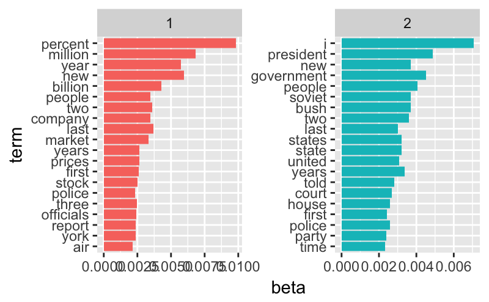

```r
library(ggplot2)
library(dplyr)
ap_top_terms_2 <- ap_topics_2 %>%
  group_by(topic) %>%
  top_n(20, beta) %>%
  ungroup() %>%
  arrange(topic, -beta)
ap_top_terms_2 %>%
  mutate(term = reorder(term, beta)) %>%
  ggplot(aes(term, beta, fill = factor(topic))) +
  geom_col(show.legend = FALSE) +
  facet_wrap(~ topic, scales = "free") +
  coord_flip()
```

What if we run the model again with a larger number of topics. Let’s try 15:

```r
ap_lda_15 <- LDA(AssociatedPress, k = 15, control = list(seed=1234))
ap_lda_15
```

```
A LDA_VEM topic model with 15 topics.
```

```r
ap_topics_15 <- tidy(ap_lda_15, matrix="beta")
ap_topics_15
```

| topic | term | beta |
| --- | --- | --- |
| 1 | aaron | 6.597540e-19 |
| 2 | aaron | 5.751733e-05 |
| 3 | aaron | 1.610906e-304 |
| 4 | aaron | 1.550161e-37 |
| 5 | aaron | 1.249799e-20 |
| 6 | aaron | 2.515955e-24 |
| 7 | aaron | 2.015628e-04 |
| 8 | aaron | 1.979752e-47 |
| 9 | aaron | 5.725690e-240 |
| 10 | aaron | 3.408042e-05 |

[output cut: 990 more lines]

[figure not shown]

```r
ap_top_terms_15 <- ap_topics_15 %>%
  group_by(topic) %>%
  top_n(10, beta) %>%
  ungroup() %>%
  arrange(topic, -beta)
ap_top_terms_15 %>%
  mutate(term = reorder(term, beta)) %>%
  ggplot(aes(term, beta, fill = factor(topic))) +
  geom_col(show.legend = FALSE) +
  facet_wrap(~ topic, scales = "free") +
  coord_flip()
```

One thing you’ll notice about topic modeling is that certain words will overlap across topics. Other methods of analysis (forms of clustering) don’t allow for this overlap.

Topic modeling doesn’t just estimate each topic as a mixture of words, it also can estimate the degree to which each document is a mixture of topics. This is called the per-document-per-topic probabilities (“gamma”). We can investigate this using tidy() with the matrix = “gamma” argument:

```r
ap_documents <- tidy(ap_lda_2, matrix = "gamma")
ap_documents
```

| document | topic | gamma |
| --- | --- | --- |
| 1 | 1 | 0.2480616686 |
| 2 | 1 | 0.3615485445 |
| 3 | 1 | 0.5265844180 |
| 4 | 1 | 0.3566530023 |
| 5 | 1 | 0.1812766762 |
| 6 | 1 | 0.0005883388 |
| 7 | 1 | 0.7734215655 |
| 8 | 1 | 0.0044516994 |
| 9 | 1 | 0.9669915139 |
| 10 | 1 | 0.1468904793 |

[output cut: 990 more lines]

Its one thing to try and topic model data that is already pre-packaged and ready to go but its something different altogether to work with your own data. Let’s see a few different ways that we can work with data that we have to import ourselves.

First let’s erase some of the data we don’t need anymore to free up some memory:

```r
rm(ap_documents)
rm(ap_top_terms_15)
rm(ap_topics_15)
rm(ap_lda_15)
rm(ap_lda_2)
rm(AssociatedPress)
```

Next, let’s load the files from our CanLit corpus.

The files in your “CanLit” directory are plaintext (mostly – with the exception of a few weird characters) copies of issues of the journal “Canadian Literature.” What might we learn about the state of Canadian literature, about editorial decisionmaking, about what authors get discussed together if we engage in a topic modeling of the journal?

First thing we’ll do is try and load the files directly into R.

```r
Sys.setlocale(locale="LC_All", locale="English")
```

[output not shown]

Note that this would data importing activity would actually be a lot easier if our data was in a handy format that R can just automatically import like CSV. CSV (Comma Separated Values) is a kind of data format where values are separated by commas. You can read CSV files in most text editors or in a spreadsheet program. CSV is especially convenient for R because we can actually just import the data using the “Import Dataset” button in the corner of RStudio.

```r
class(CanLit_dataset)
```

```
[1] "data.frame"
```

This is often a useful format to have it in but right now we don’t actually need our data in a data frame. We need something slightly different – a corpus. We could actually convert our data frame into a corpus, but it would require a lot of steps. Luckily, R has a much easier way to do all of this (so then why did I get you to do that in the first place!!?) :

```r
#Load the Topic Modeling library
library(tm)
#This actually just loads the files from the CanLit directory into a
CanLit_corpus <- Corpus(DirSource(path))
CanLit_corpus
```

```
<<SimpleCorpus>>
Metadata:  corpus specific: 1, document level (indexed): 0
Content:  documents: 211
```

```r
filenames <- list.files("/Users/paulbarrett/Dropbox/Teaching/DHSI/CanLit/", pattern="*.txt")
```

This has created a ‘corpus’ (a collection of documents) out of all of our texts. Pretty easy!

Actually it turns out there’s an even EASIER way to do this. Let’s use another method for ingesting this data: Quanteda. Quanteda works very well with the tm (textmining) library to prepare your data for textual analysis. The basic process here, to prepare our data for topic modeling, is that we have to read in the text files, convert them into a corpus, and then turn that corpus into a Document Frequency Matrix (DFM). We could do all of this manually (as you saw a little bit above) but Quanteda makes this much easier.

Full disclosure: When creating this notebook I didn’t know about Quanteda so I did all of this using the tm library – it took about 100 lines of code. Then I learned about Quanteda and realized it could all be done with about 4 commands. Quanteda had made easy (and better) functions to automatically do all of the things I tried to manually code. The lesson: google first and code later!

```r
library(quanteda)
library(readtext)
# readtext() is a simple method for reading all of the files in that directory. This replaces the big, ugly for loop that we had in our first chunk of code. Simple:
CanLitFiles <- readtext("/Users/paulbarrett/Dropbox/Teaching/DHSI/CanLit/*.txt")
#Now we create a CanLit_corpus out of the raw text that we've read
CanLit_corpus_readtext <- corpus(CanLitFiles)
```

OK, so we *think* we’ve created a corpus. Let’s have a look to see what we’ve built:

```r
#Lets take a look at what our corpus looks like:
class(CanLit_corpus_readtext)
```

```
[1] "corpus" "list"
```

```r
summary(CanLit_corpus_readtext)
```

```
Corpus consisting of 211 documents, showing 100 documents.

             Text Types Tokens Sentences
    CanLit001.txt  9253  44467      1606
    CanLit002.txt  9097  43431      1624
    CanLit003.txt 10541  52143      3013
    CanLit004.txt  9334  42475      1595
    CanLit005.txt  8553  43875      1719
    CanLit006.txt  9570  46615      1725
    CanLit007.txt 10632  54097      3344
    CanLit008.txt  9828  45789      2222
    CanLit009.txt  8909  42604      2131
    CanLit010.txt  8652  39918      1426
    CanLit011.txt 11751  58605      4271
    CanLit012.txt  7910  41436      1533
    CanLit013.txt  8781  43468      1596
    CanLit014.txt 10186  55924      3326
    CanLit015.txt 10620  55086      3670
    CanLit016.txt  8640  41098      1560
    CanLit017.txt  8563  43486      1561
    CanLit018.txt  8684  38272      1605
    CanLit019.txt 10363  51795      4013
    CanLit020.txt  7203  37580      1455
    CanLit021.txt  7571  39483      1485
    CanLit022.txt  7784  37951      1432
    CanLit023.txt  9850  51621      3311
    CanLit024.txt  7916  38657      1428
    CanLit025.txt  7688  38395      1403
    CanLit026.txt  7902  40449      1529
    CanLit027.txt 10353  53449      3236
    CanLit028.txt  7553  36158      1260
    CanLit029.txt  7802  43741      1681
    CanLit030.txt  7765  36686      1367
    CanLit031.txt  8095  40377      1572
    CanLit032.txt 10769  57714      3622
    CanLit033.txt  8676  46627      1902
    CanLit034.txt  9064  51261      1918
    CanLit035.txt  9044  49363      1970
    CanLit036.txt 12552  66953      3823
    CanLit037.txt  9645  45936      1719
```

[output cut: 52 more lines]

```
    CanLit090.txt 16730 119706      4654
    CanLit091.txt 17148 107240      4161
    CanLit092.txt 16036 108142      3897
    CanLit093.txt 17201 102695      3664
    CanLit094.txt 18088 116541      4310
    CanLit095.txt 18310 117387      4620
    CanLit096.txt 19105 111567      4350
    CanLit097.txt 13520  70537      2414
    CanLit098.txt 20104 124970      4546
    CanLit100.txt 20090 141483      5679
    CanLit101.txt 19018 123775      4559

Source:  /Users/paulbarrett/Dropbox/Teaching/DHSI/* on x86_64 by paulbarrett
Created: Tue Jun 13 17:43:26 2017
Notes:
```

This looks good! Remember, a corpus is just a fancy way of describing a collection of works that have been formatted to interact with some of R’s functions. A corpus could be any collection of objects you want to investigate: 100 novels, 1000 astronomical charts, 500 letters, 10,000 pictures of your cat. Whatever…

Notice that CanLit_corpus_readtext isn’t just a corpus. It’s actually a combined data format that includes a corpus and a list.

Now that we have our corpus, we can easily turn our corpus into a document feature matrix. A document fearture matrix is similar to a document term matrix: both are big tables that tell us how many times every word in a corpus occurs in a particular document in that corpus.

```r
#Create a list of stopwords
CanLit_Stopwords = c(stopwords("english"), stopwords("french"), "amprftvalfmtinfo", "ericamprftidinfo", "mtx", "ofifmt", "sfxscholarsportalinfomcmasterurlverz", "authoraffil", "authoraffili", "tion", "p", "ing", "ia")
#Create a Document Feature Matrix
CanLit_dfm <- dfm(CanLit_corpus_readtext, remove = CanLit_Stopwords, stem = TRUE, remove_punct = TRUE)
```

There are a few things going on here:

The first thing I’ve done is create a list of ‘stopwords’. CanLit_Stopwords uses the ‘c’ command (concatenate) to put together a big list of words that we don’t want to be included in the document frequency matrix. These are words like “he,” “the,” “a,” “i” – words that are so generic they won’t be useful for any kind of analysis.

The first part of the list uses the command stopwords(“english”) to remove standard english stopwords, then stopwords(“french”) to remove the french stopwords (since Canadian Literature is a bilingual journal) and then I’ve appended a small list of custom words that I know appear in this corpus. We can edit this custom list (and even make it more formal by storing it in a custom stopwords file somewhere) as needed.

Once we have defined our CanLit_Stopwords, we call the command dfm with a series of arguments (the things in the brackets separated by commas).

Arguments allow us to customize how we want the command to be run. So if we’re not picky we might just run a command like:

Coffee(medium)

which would get us back whatever the ‘default’ settings of a medium coffee happen to be. If you’re like me, you’d run it like:

Coffee(medium, roast = dark roast, sugars = 2, milk = 1, cup size = grande, name = Paul)

In this case we have four arguments associated with our dfm command: input, remove, stem, remove_punct. As with the coffee example, most of the arguments here are optional. In the coffee example the only thing the function really needs to know is the size of your coffee; the rest can be customized only if you want to customize it.

Lets look at the arguments that I’m including for dfm:

remove = CanLit_Stopwords – This tells the dfm to remove a selection of English, French, and CanLit custom stopwords from the corpus.

stem = TRUE – This tells dfm to stem words. The idea is that in the case of words with suffixes (governing, government, governable, governor) we are really interested in the root word: govern. So we trim the suffix from these words to make them all group together. This is a bit of an imprecise process though as sometimes these terms (stating, stately) aren’t really related.

remove_punct = TRUE – This tells dfm to remove punctuation.

Most of these arguments are in the interest of ‘scrubbing’ the data – removing the things we don’t care about (stopwords, punctuation marks, etc…) so we are really only analyzing the parts of the text that are actually meaningful for our work.

As data cleaning goes, this is a pretty crude and basic version of it. If we really wanted to substantially clean our data we’d need to go through this cleaning process a few times and probably write a script (in R or Python or a similar language) that cleans the data very well. But for our purposes, this is probably good enough.

OK, so what have we actually createed?

```r
CanLit_dfm
```

```
Document-feature matrix of: 211 documents, 256,341 features (96.1% sparse).
```

OK – interesting, but what does that actually tell us? Not much. But there a few tools that can give us a wider view of the DFM & corpus. Topfeatures is a useful command for understanding the more significant dimensions of the DFM:

```r
CanLit_Top100 <- topfeatures(CanLit_dfm, 100)
CanLit_Top100
```

```
      one  canadian      book      work      poem     stori      like     write     novel      life      time
    48613     39885     39373     30103     28839     27768     27730     24610     24102     23879     23245
   canada       new     world      also       can     first       way      make      will    cultur    narrat
    23076     22879     22636     22584     21596     21388     18802     18658     18573     18472     18389
      two      even      read    writer literatur       man       use    reader    critic      poet      live
    17755     17311     17111     16724     16509     16008     15716     15664     15613     15586     15461
     text   histori      seem        us    review       see    poetri     peopl     place      much      mani
    15315     15298     14973     14914     14801     14606     14394     14385     14318     14078     14076
     year      part      word      form      come       may     becom     women      well      love   charact
    13942     13615     13265     13031     12976     12934     12920     12811     12647     12571     12411
    natur  literari   languag      play       say    author     point      sens       end    differ   present
    12332     12313     12108     12103     11966     11916     11873     11608     11453     11440     11294
     take   collect    nation   toronto       now   fiction     polit      mean      find    experi     howev
    11095     11075     11031     10913     10908     10848     10848     10574     10549     10455     10444
  publish     human    social       art   univers       yet    person     thing     studi    rather      imag
    10396     10385     10343     10255     10217     10114     10097      9979      9903      9800      9775
     know      just     anoth      note  interest     power     think      call  american  question      long
     9764      9553      9435      9428      9414      9260      9244      9150      9130      9068      9065
     must
     9036
```

We can visualize this relatively easily in a word cloud:

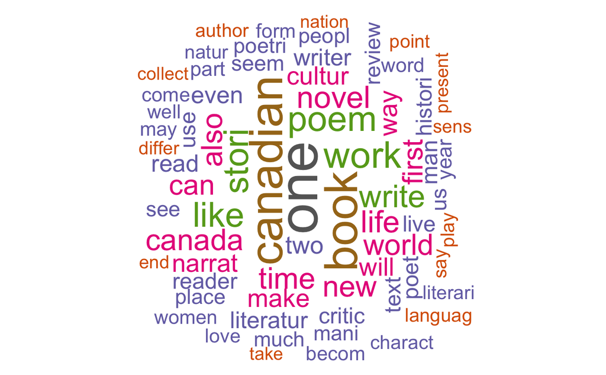

```r
library(wordcloud)
set.seed(100)
textplot_wordcloud(CanLit_dfm, min.freq = 11000, random.order = FALSE,
                   rot.per = .25,
                   colors = RColorBrewer::brewer.pal(8,"Dark2"))
```

We can also plot these values pretty easily:

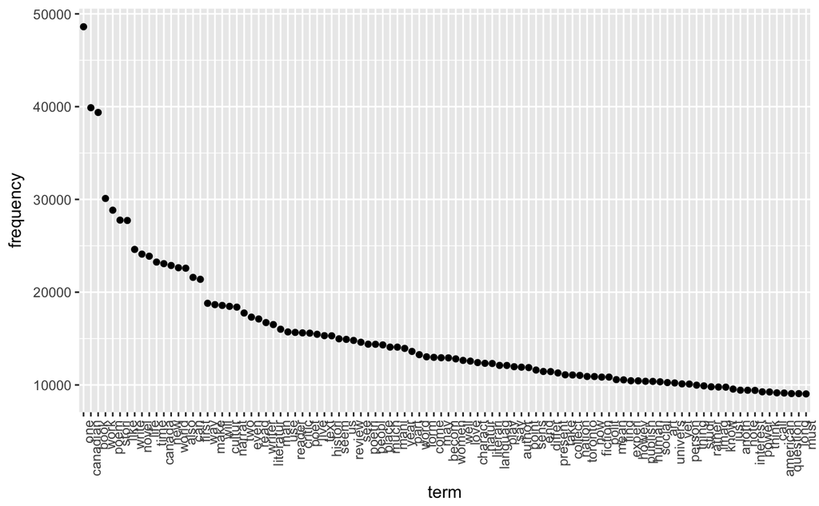

```r
library(ggplot2)
# Create a data.frame for ggplot
topDf <- data.frame(
    list(
        term = names(CanLit_Top100),
        frequency = unname(CanLit_Top100)
    )
)
# Sort by reverse frequency order
topDf$term <- with(topDf, reorder(term, -frequency))
ggplot(topDf) + geom_point(aes(x=term, y=frequency)) +
    theme(axis.text.x=element_text(angle=90, hjust=1))
```

These are interesting, but if we want to be a bit more focused and look at some of the patterns more closely, we can generate some lexical dispersion plots. LDPs basically track how often a term gets used across a corpus. So we can see how often different writers are discussed in the journal:

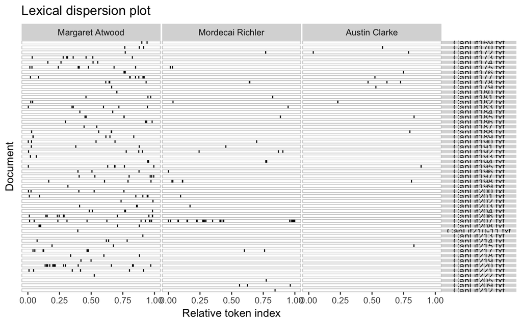

```r
textplot_xray(
     kwic(CanLit_corpus_readtext[160:211], "Margaret Atwood"),
     kwic(CanLit_corpus_readtext[160:211], "Mordecai Richler"),
     kwic(CanLit_corpus_readtext[160:211], "Austin Clarke")
)
```

Another useful operation is ‘kwic’ – keyword in context – which provides some useful information about a particular keyword across a corpus:

```r
kwic(CanLit_corpus_readtext, "Austin Clarke", window = 3)
```

```
   [CanLit038.txt, 49700:49701]      English language. | AUSTIN CLARKE | IN CANADIAN REVIEWS
   [CanLit038.txt, 50677:50678]              is not an | Austin Clarke | fantasy, but
   [CanLit041.txt, 60433:60434]             dead. When | Austin Clarke | , in his
   [CanLit051.txt, 39552:39553]          TO WEAR SILKS | Austin Clarke | $ 2.75 Anansi
   [CanLit054.txt, 38654:38655]    DAY Donald Stephens | AUSTIN CLARKE | , When He
   [CanLit059.txt, 40572:40573]      come writers like | Austin Clarke | and Michael Ondaatje
   [CanLit061.txt, 54198:54199]         HERE AND THERE | AUSTIN CLARKE | , Storm of
   [CanLit061.txt, 55111:55112]              the book. | Austin Clarke | is not writing
     [CanLit066.txt, 9409:9410]         John Peter and | Austin Clarke | , we find
   [CanLit076.txt, 58525:58526]             Hugh Hood, | Austin Clarke | , Jane Rule
   [CanLit089.txt, 73065:73066]         LIES AND GRACE | AUSTIN CLARKE | , Growing Up
   [CanLit089.txt, 73104:73105]         THE MEMOIRS OF | AUSTIN CLARKE | , fiction writer
         [CanLit094.txt, 29:30]          EARLE BIRNEY, | AUSTIN CLARKE | , CLEMENT H
     [CanLit094.txt, 1261:1262]             those few( | Austin Clarke | , for example
   [CanLit094.txt, 14698:14699]           OF THE NORTH | Austin Clarke | GOING STRAIGHT NORTH
 [CanLit094.txt, 107728:107729]     Caribbean and read | Austin Clarke | , writes about
 [CanLit094.txt, 110363:110364]                 424. a | Austin Clarke | , The Prime
 [CanLit094.txt, 110396:110397]                   ). 5 | Austin Clarke | ," Some
   [CanLit108.txt, 79440:79441]                  . g5. | AUSTIN CLARKE | , When Women
   [CanLit120.txt, 75924:75925]             Klein, and | Austin Clarke | fit well into
 [CanLit124.txt, 181894:181895]  BAILEY ISLAND SCHOLAR | AUSTIN CLARKE | , Proud Empires
   [CanLit132.txt, 52210:52211]       the pattern with | Austin Clarke | , Canada's major
   [CanLit135.txt, 70353:70354]       Steve Vizinczey, | Austin Clarke | , Brian Moore
   [CanLit150.txt, 49882:49883]          Indies$ 14.95 | Austin Clarke | A Passage Back
     [CanLit157.txt, 3222:3223]   Clarke Antiphony For | Austin Clarke | Those chalk-
   [CanLit158.txt, 81647:81648]            Sam Selvon, | Austin Clarke | , Dionne Brand
   [CanLit158.txt, 97699:97700]                  ), or | Austin Clarke | constructing a defensive
   [CanLit158.txt, 99464:99465]          Shadbolt; The | Austin Clarke | Reader, ed
   [CanLit161.txt, 80603:80604]            the work of | Austin Clarke | and Michael Ondaatje
   [CanLit164.txt, 77045:77046]           House$ 29.95 | Austin Clarke | The Origin of
   [CanLit164.txt, 86404:86405]              , such as | Austin Clarke | , Dionne Brand
   [CanLit165.txt, 66616:66617]      Elliott Clarke on | Austin Clarke | , and Wayde
   [CanLit167.txt, 96016:96017]                House), | Austin Clarke | ( The Question
   [CanLit168.txt, 87653:87654]          Wear Silks by | Austin Clarke | and h.
   [CanLit170.txt, 91002:91003]     of Cultural Memory | Austin Clarke | Pigtails' n
   [CanLit170.txt, 91099:91100]       Dionne Brand and | Austin Clarke | . The construction
     [CanLit172.txt, 3978:3979]            Hungary. Or | Austin Clarke | , for his
   [CanLit172.txt, 88924:88925]        such writers as | Austin Clarke | and Dionne Brand
   [CanLit176.txt, 87971:87972]          Ondaatje, and | Austin Clarke | . It is
   [CanLit177.txt, 59892:59893]            of works by | Austin Clarke | , Dany Laferriere
   [CanLit178.txt, 57643:57644] . Colonial Confessions | Austin Clarke | The Polished Hoe
   [CanLit178.txt, 76025:76026]              Tom King, | Austin Clarke | , Rohinton Mistry
   [CanLit178.txt, 89286:89287]            1870s West, | Austin Clarke | on 1950s Barbados
   [CanLit179.txt, 62286:62287]            the Answer? | Austin Clarke | The Question.
   [CanLit182.txt, 29887:29888]          what else has | Austin Clarke | done, for
   [CanLit182.txt, 29923:29924]               saying," | Austin Clarke | is the first
   [CanLit185.txt, 99119:99120]        David Odhiambo, | Austin Clarke | and Nalo Hopkinson
   [CanLit188.txt, 94135:94136]           or topics as | Austin Clarke | , Robert Majzels
 [CanLit195.txt, 104545:104546]          Ayanna Black, | Austin Clarke | , George Elliott
 [CanLit195.txt, 104631:104632]      . The redoubtable | Austin Clarke | , for instance
 [CanLit195.txt, 104665:104666]        We already have | Austin Clarke | ," as
   [CanLit198.txt, 89295:89296]       Dionne Brand and | Austin Clarke | is unfortunate and
   [CanLit215.txt, 93922:93923]    - Caribbean writers | Austin Clarke | and Cecil Foster
```

We can also tokenize our text quite easily:

```r
CanLit_tokens <- tokens(CanLit_corpus_readtext)
```

Maybe, we’d like to clean up our tokens a bit, or just tokenize sentences rather than individual words:

```r
CanLit_tokens <- tokens(CanLit_corpus_readtext, remove_numbers = TRUE, remove_punct = TRUE,  what="sentence")
```

We might also want to plot the similarities of documents in our corpus

```r
CanLit_Simil <- textstat_simil(CanLit_dfm, c("CanLit150.txt" , "CanLit200.txt"),
                             margin = "documents", method = "cosine")
CanLit_Simil
```

```
                 CanLit150.txt CanLit200.txt
CanLit150.txt        1.0000000     0.8119337
CanLit200.txt        0.8119337     1.0000000
CanLit001.txt        0.7661456     0.7404899
CanLit002.txt        0.7658611     0.7361686
CanLit003.txt        0.7024897     0.7097237
CanLit004.txt        0.7473299     0.7269788
CanLit005.txt        0.7341692     0.7242524
CanLit006.txt        0.7727476     0.7372281
CanLit007.txt        0.6748863     0.6826088
CanLit008.txt        0.7171624     0.6915430
CanLit009.txt        0.6892694     0.6714532
CanLit010.txt        0.7444527     0.7265420
CanLit011.txt        0.5767400     0.6094449
CanLit012.txt        0.7729960     0.7516940
CanLit013.txt        0.7452645     0.7282390
CanLit014.txt        0.6034114     0.6163207
CanLit015.txt        0.6160971     0.6114519
CanLit016.txt        0.7315529     0.7046639
CanLit017.txt        0.7052948     0.6937338
CanLit018.txt        0.7275376     0.7285560
CanLit019.txt        0.5319422     0.5523639
CanLit020.txt        0.6894080     0.6822453
CanLit021.txt        0.7649208     0.7218305
CanLit022.txt        0.7094644     0.6825709
CanLit023.txt        0.6805536     0.6669378
CanLit024.txt        0.7527156     0.7266194
CanLit025.txt        0.6668174     0.6242204
CanLit026.txt        0.7597116     0.7027963
CanLit027.txt        0.6832615     0.6912757
CanLit028.txt        0.7430096     0.6793130
CanLit029.txt        0.7607867     0.7022220
CanLit030.txt        0.7269498     0.6871424
CanLit031.txt        0.7774989     0.7394547
CanLit032.txt        0.6726950     0.6633268
CanLit033.txt        0.5836407     0.6014733
CanLit034.txt        0.7765114     0.7051607
CanLit035.txt        0.6413969     0.6273984
CanLit036.txt        0.6970994     0.6974008
CanLit037.txt        0.6924205     0.7003585
```

[output cut: 157 more lines]

```
CanLit207.txt        0.6935633     0.7498798
CanLit208.txt        0.7453959     0.8215112
CanLit209.txt        0.7407907     0.8251177
CanLit210-11.txt     0.7129002     0.6887899
CanLit212.txt        0.8333546     0.8377976
CanLit213.txt        0.7293124     0.7663538
CanLit214.txt        0.7932065     0.8362684
CanLit215.txt        0.7523292     0.8266922
CanLit216.txt        0.7686197     0.8170395
CanLit217.txt        0.8009135     0.8151148
CanLit218.txt        0.7907651     0.7985447
CanLit219.txt        0.8138694     0.8134431
CanLit220.txt        0.7624817     0.7960759
CanLit221.txt        0.8007013     0.8278154
CanLit222.txt        0.7718116     0.7364008
```

We can also calculate lexical diversity:

```r
textstat_lexdiv(CanLit_dfm, measure = c("CTTR", "Maas"), log.base = 10)
```

|  | CTTR | Maas | lgV0 | lgeV0 |
| --- | --- | --- | --- | --- |
| CanLit001.txt | 31.52757 | 0.1651685 | 8.086785 | 18.62051 |
| CanLit002.txt | 31.28095 | 0.1650379 | 8.082619 | 18.61092 |
| CanLit003.txt | 33.67566 | 0.1632361 | 8.249359 | 18.99485 |
| CanLit004.txt | 33.09255 | 0.1609286 | 8.329505 | 19.17939 |
| CanLit005.txt | 30.09627 | 0.1676326 | 7.929572 | 18.25852 |
| CanLit006.txt | 32.12098 | 0.1646791 | 8.130082 | 18.72021 |
| CanLit007.txt | 32.89907 | 0.1659342 | 8.107256 | 18.66765 |
| CanLit008.txt | 34.34901 | 0.1593004 | 8.449400 | 19.45546 |
| CanLit009.txt | 31.54085 | 0.1643633 | 8.121069 | 18.69945 |
| CanLit010.txt | 30.93074 | 0.1646566 | 8.084797 | 18.61593 |

[output cut: 201 more lines]

We can do a lot with our DFM, but for topic modeling we need to convert our corpus into a Document Term Matrix. Actually, strictly speaking this isn’t completely true – our topic modeling algorithm will still work with a DFM but it requires some tricky conversion and seems to run a lot slower. So we’re going to convert our corpus into a DTM to make things a bit easier:

Lets make it a few different ways to compare the results:

```r
#We create our Document Term Matrix out of the CanLit corpus.
#The convert function easily transforms our DFM to a format appropriate for topic modeling work.
CanLit_DTM <- convert(CanLit_dfm, to = "topicmodels")
class(CanLit_DTM)
```

```
[1] "DocumentTermMatrix"    "simple_triplet_matrix"
```

```r
CanLit_DTM_2 <- DocumentTermMatrix(CanLit_corpus)
class(CanLit_DTM_2)
```

```
[1] "DocumentTermMatrix"    "simple_triplet_matrix"
```

Notice that when we create CanLit_DTM_2 we’re using “CanLit_corpus” and not “CanLit_corpus_readtext”. The reason for this is because CanLit_corpus_readtext is a data object that combines a corpus and a list whereas CanLit_corpus is just a corpus. Because DocumentTermMatrix() will only accept a corpus as its input, we can either strip the list from CanLit_corpus_readtext to make it acceptable input or just use CanLit_corpus.

It shouldn’t really make a huge difference which method you use. Experiment and see which one generates the best results (smallest memory imprint).

Now we have our CanLit Document Term Matrix. Again, this is a huge table where the rows are the corpus items and the columns are the words that appear in the corpus. Any given cell tells us how many times that particular word appears in that particular corpus item.

We can actually take two approaches to reducing the size of our matrix. To do this, we’ll create new DTMs using (DocumentTermMatrix) but telling the algorithm to exclude words that don’t appear very often or that are (according to their TF-IDF rating) less relevant to the corpus as a whole. Can you think of methods that you might use to reduce the DTM?

Let’s try both approaches:

```r
CanLit_DTM_Slim1 <-DocumentTermMatrix (CanLit_corpus, control = list(removePunctuation = TRUE, stopwods = TRUE, weighting = function(x) weightTfIdf(x, normalize = FALSE)))
CanLit_DTM_Slim1
```

```
<<DocumentTermMatrix (documents: 211, terms: 270084)>>
Non-/sparse entries: 2629696/54358028
Sparsity           : 95%
Maximal term length: 81
Weighting          : term frequency - inverse document frequency (tf-idf)
```

```r
CanLit_DTM_Slim2 <- DocumentTermMatrix(CanLit_corpus, control = list(removePunctuation = TRUE, stopwords = TRUE ))
CanLit_DTM_Slim2 <- removeSparseTerms(CanLit_DTM_Slim2, 0.8)
CanLit_DTM_Slim2
```

```
<<DocumentTermMatrix (documents: 211, terms: 16053)>>
Non-/sparse entries: 1671477/1715706
Sparsity           : 51%
Maximal term length: 18
Weighting          : term frequency (tf)
```

removeSparseTerms can substantially reduce the size of our DTM but by excluding terms we are changing our input data. In your own work you’ll likely want to find a balance between shrinking your matrix to an appropriate size and not reducing your corpus too much.

Now that we have our relatively slim DTM, let’s try actually topic modeling our corpus.

```r
library(topicmodels)
library(tm)

k <- 10

# What other stopwords might we add?

CanLit_lda_10 <- LDA (CanLit_DTM_Slim2, k)
CanLit_lda_10_posterior <- posterior (CanLit_lda_10)
get_terms(CanLit_lda_10, 10)
topics(CanLit_lda_10, 3)
```

[output not shown]